# Assignment 16: Writing a function - Loop

Hint: [Similar function](https://bryantstats.github.io/math421/gganimate/18_writing_functions.html#40)

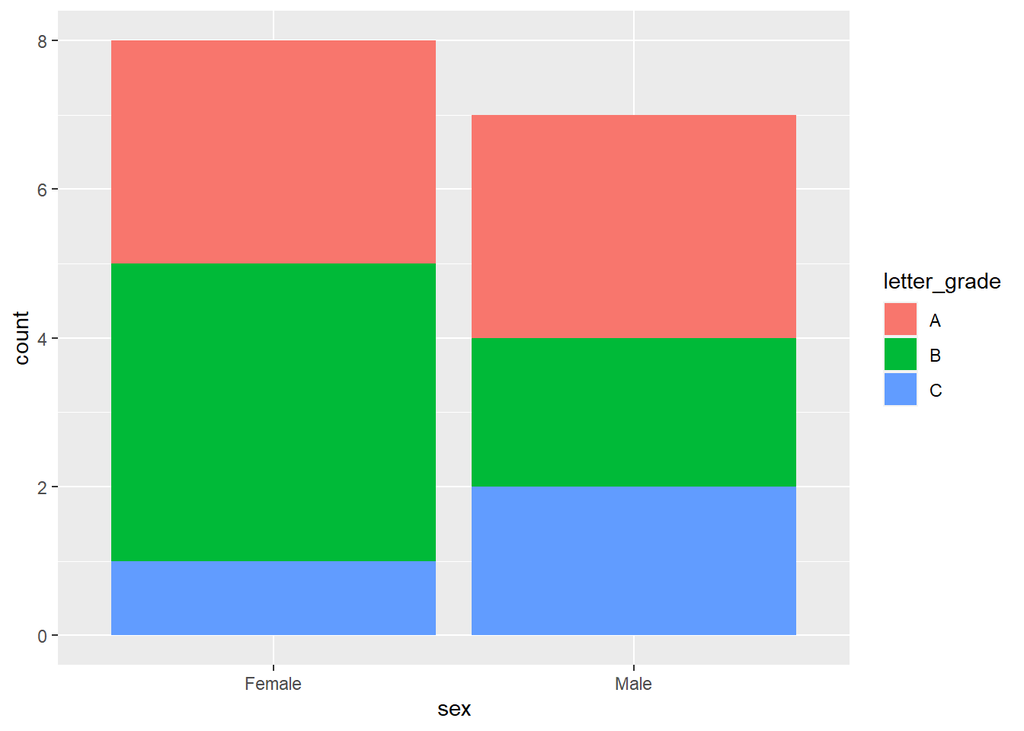

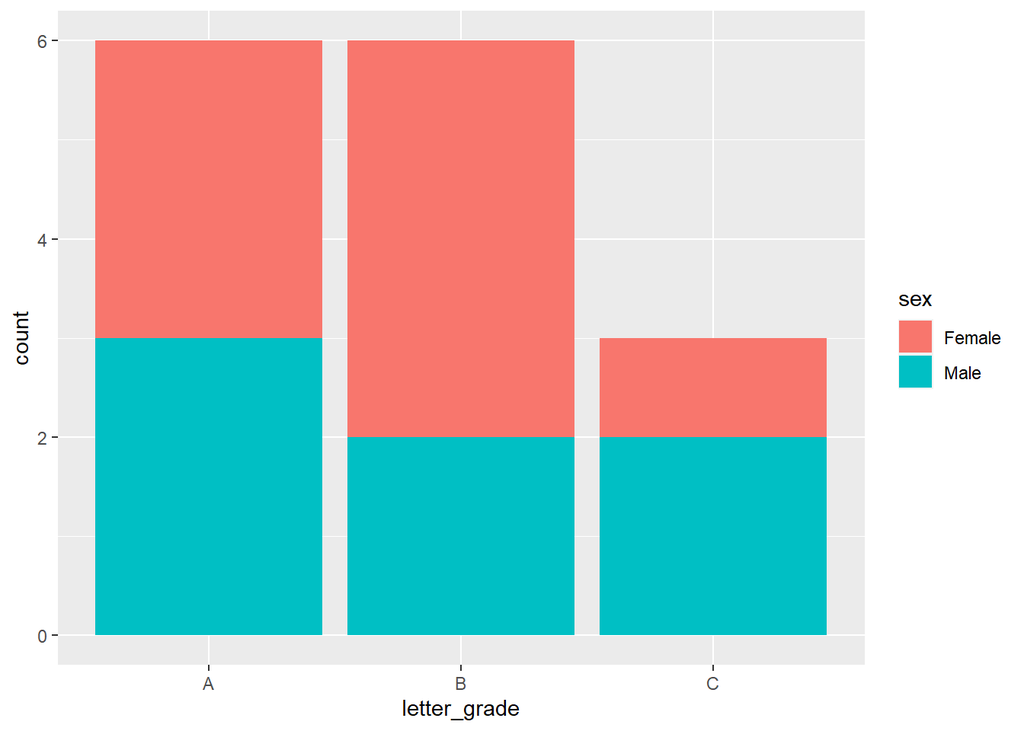

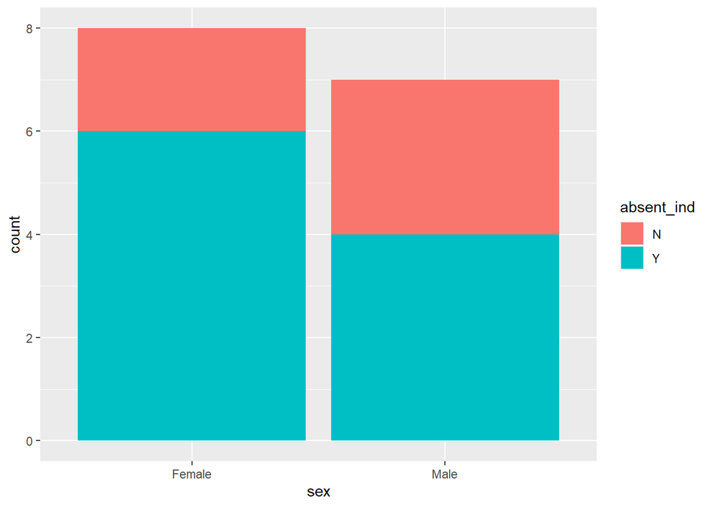

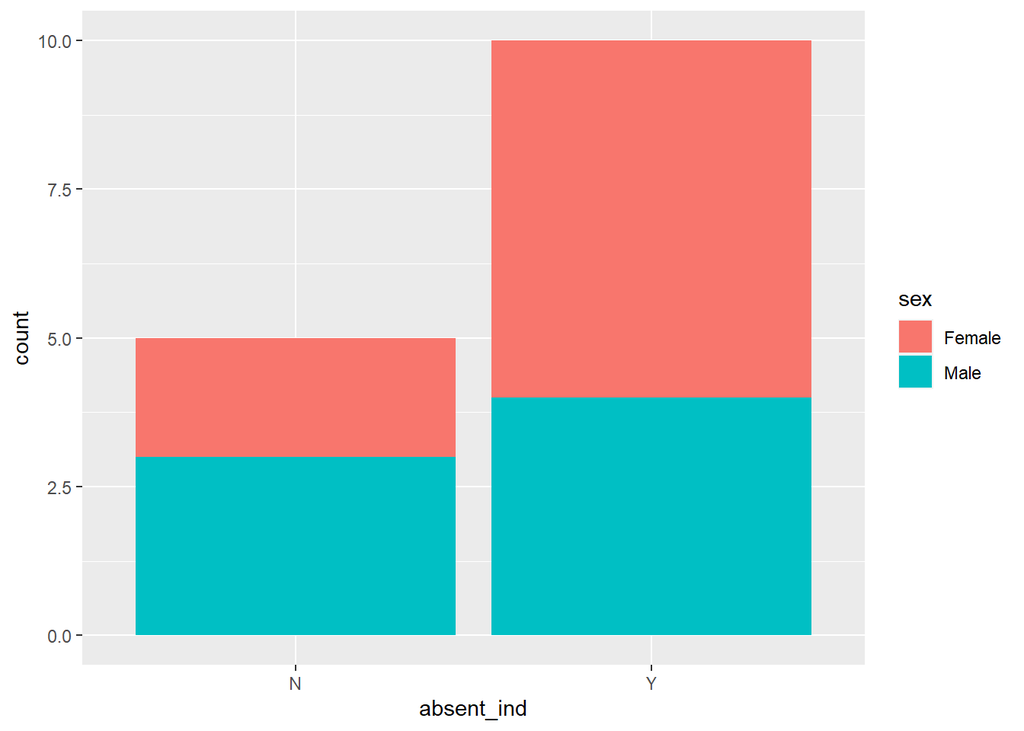

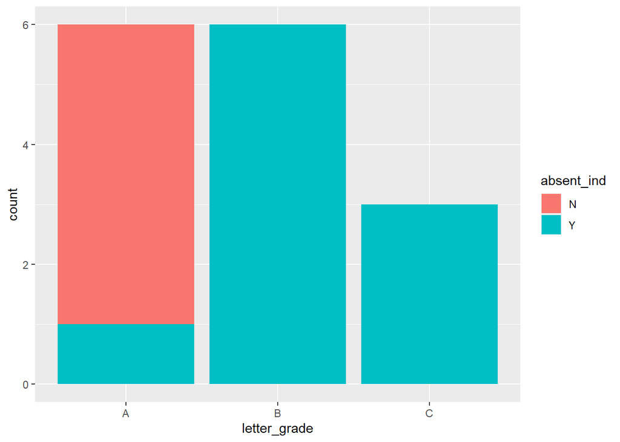

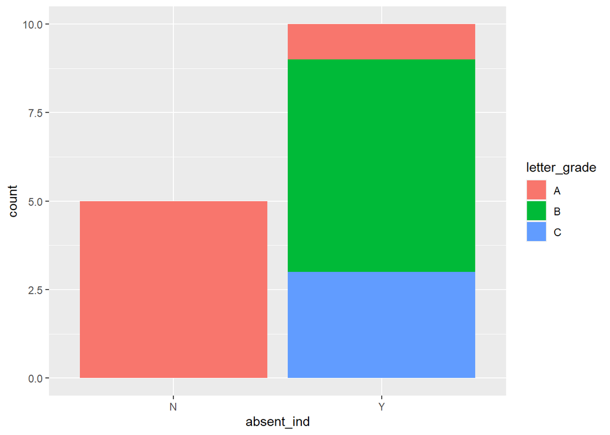

```r
all_possible_bar_plots <- function(d)
{library(ggplot2)
  for (i in 1:(length(d)-1))
  for (j in (i+1):length(d))
{if ((!is.numeric(d[[i]])) & (!is.numeric(d[[j]])))
{print(ggplot(data = d, aes(x= d[[i]], fill= d[[j]]))+ geom_bar() +
         labs(x= names(d)[i], fill = names(d)[j]))
 print(ggplot(data = d, aes(x= d[[j]], fill= d[[i]]))+ geom_bar() +
         labs(x= names(d)[j], fill = names(d)[i]))
}
}
}


# Test case: A working function will produce all of the possible bar plots from the df5 data in which a non-numeric variable can be plotted while having the bars filled with another non-numeric variable (this includes flipped pairs [i.e., a bar plot of sex filled by letter_grade and a bar plot of letter_grade filled by sex])
all_possible_bar_plots(df5)
```

5. Write the following function. Give examples to test your function.
- Input: a data frame
- Output:
  - all possible the bar plots of a non-numeric variable filled by a non-numeric variable.
  - all possible the density plots of a numeric variable colored by a non-numeric variable
  - all possible the scatter plots.

Hint: Combine [this function](https://bryantstats.github.io/math421/gganimate/18_writing_functions.html#37), [this function](https://bryantstats.github.io/math421/gganimate/18_writing_functions.html#40), and the function in Question 4. One way to combine is creating a new function, `quick_plot`, and call these three functions within `quick_plot`.

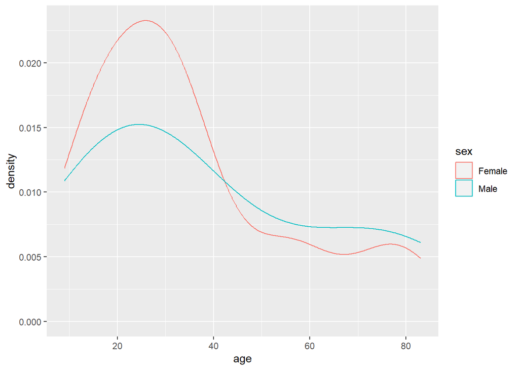

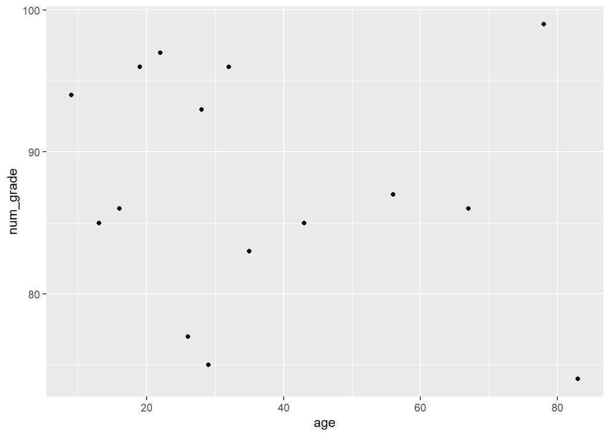

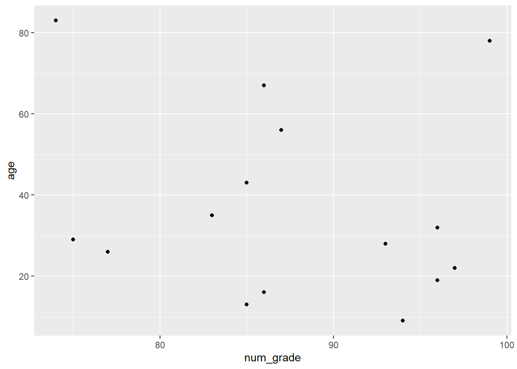

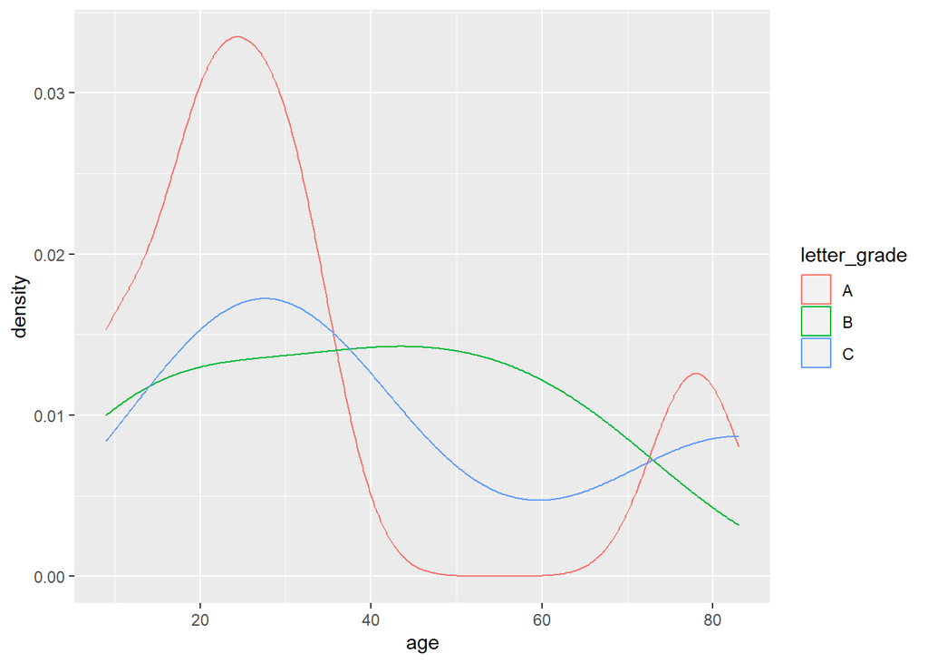

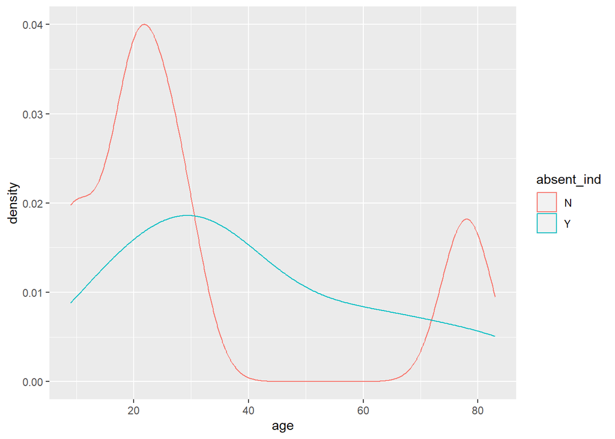

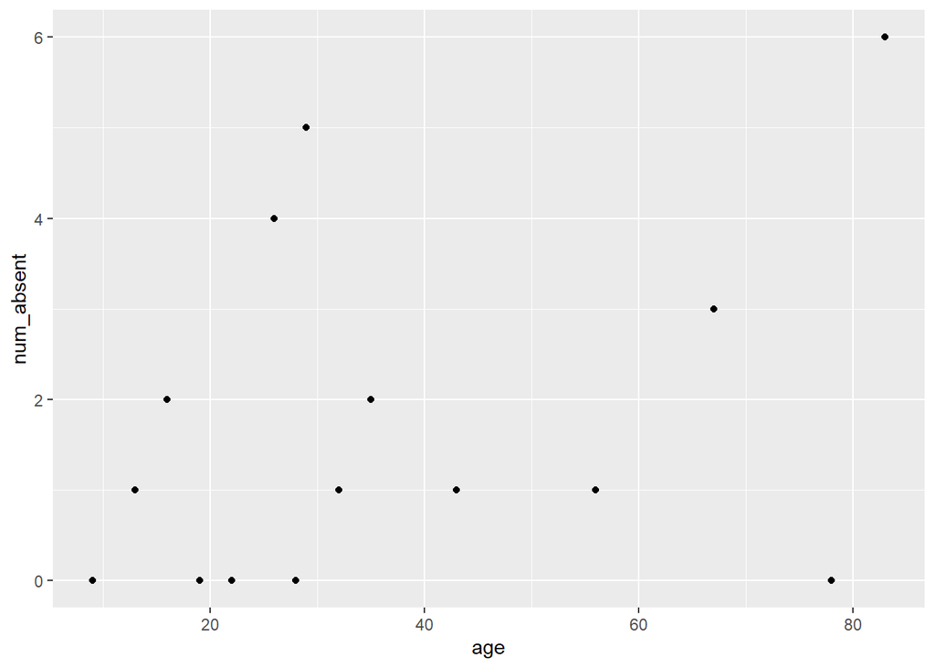

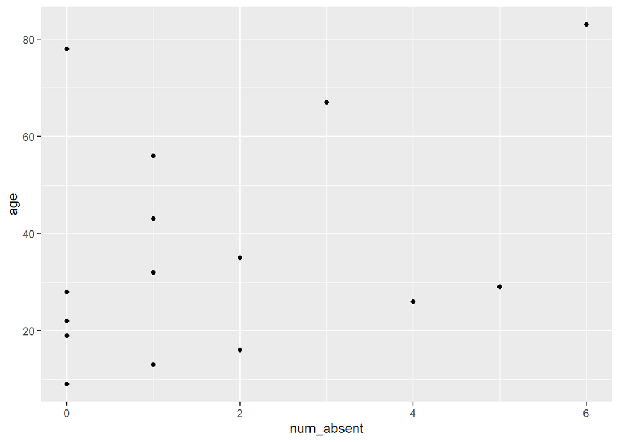

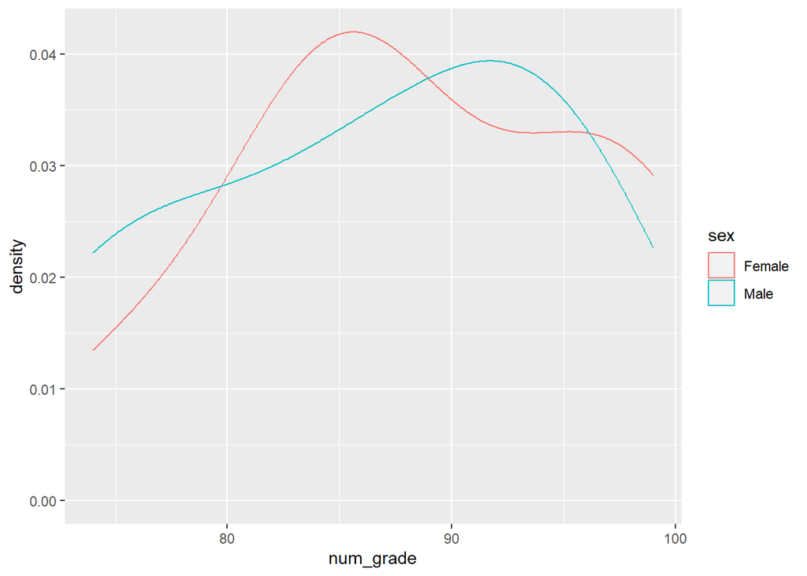

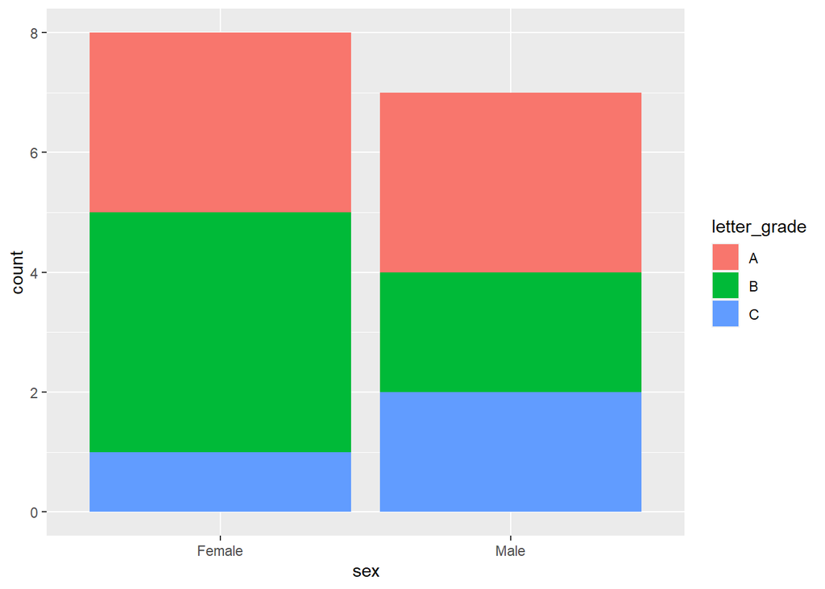

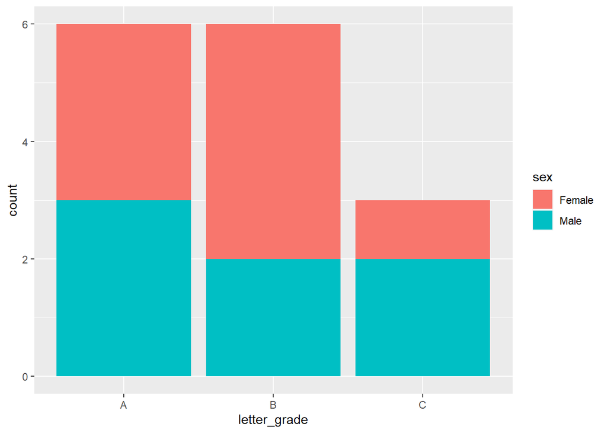

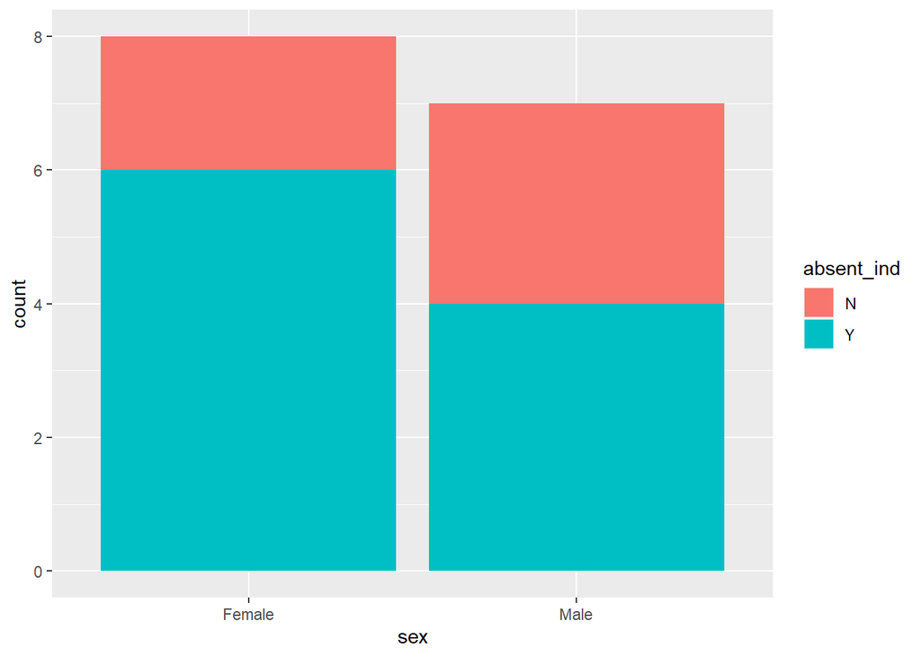

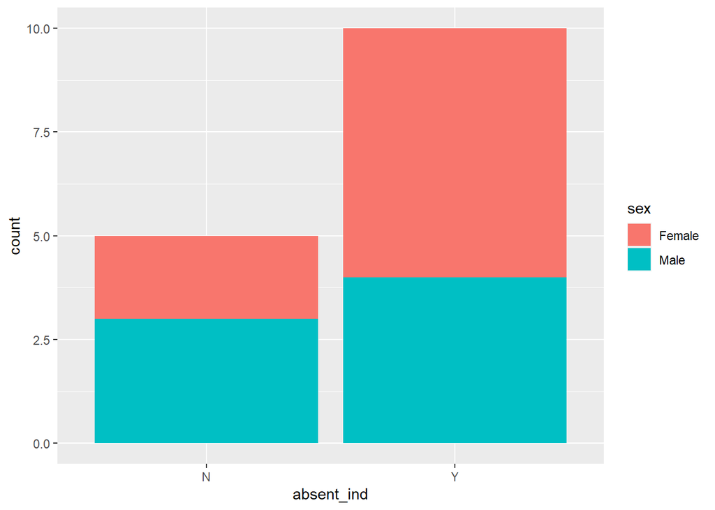

[9 more figures not shown]

```r
quick_plot <- function(d)
{library(ggplot2)
 for (i in 1:(length(d)-1))
  for (j in (i+1):length(d))
{if ((!is.numeric(d[[i]])) & (!is.numeric(d[[j]])))
{print(ggplot(data = d, aes(x= d[[i]], fill= d[[j]]))+ geom_bar() +
         labs(x= names(d)[i], fill = names(d)[j]))
 print(ggplot(data = d, aes(x= d[[j]], fill= d[[i]]))+ geom_bar() +
         labs(x= names(d)[j], fill = names(d)[i]))

}
  else if ((!is.numeric(d[[i]])) & (is.numeric(d[[j]])))
    {
    print(ggplot(d, aes(x = d[[j]], color = d[[i]]))+
              geom_density()+labs(x = names(d)[j], color = names(d)[i]))
    }
  else if ((is.numeric(d[[i]])) & (!is.numeric(d[[j]])))
  {
    print(ggplot(d, aes(x = d[[i]], color = d[[j]]))+
              geom_density()+labs(x = names(d)[i], color = names(d)[j]))
  }
  else if ((is.numeric(d[[i]])) & (is.numeric(d[[j]])))
    {
    print(ggplot(d, aes(x = d[[i]], y = d[[j]]))+
              geom_point()+
              labs(x = names(d)[i], y = names(d)[j]))
    print(ggplot(d, aes(x = d[[j]], y = d[[i]]))+
              geom_point()+
              labs(x = names(d)[j], y = names(d)[i]))
    }
  }
}

# Test case: A working function will produce all of the possible bar plots in which a non-numeric variable can be filled by another non-numeric variable (expecting 6 of these based on df5 variables), all of the possible density plots in which a numeric variable will be colored by a non-numeric variable (expecting 9 of these based on df5 variables), and all of the possible scatter plots (comprised of 2 numeric variables) (expecting 6 of these based on df5 variables)
quick_plot(df5)
```